# Bayesian GLMM Part4

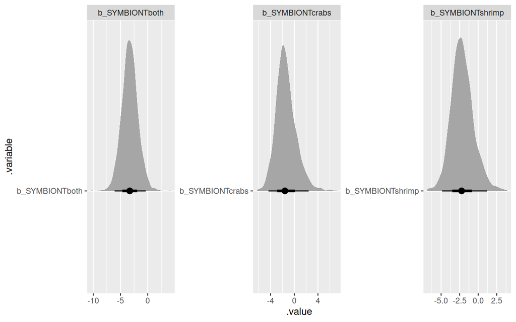

```r
mckeon_brm3 |>
    gather_draws(`^b_.*`, regex=TRUE) |>
    filter(.variable != 'b_Intercept') |>
    ggplot() +
    stat_halfeye(aes(x=.value,  y=.variable)) +
    facet_wrap(~.variable, scales='free')
```

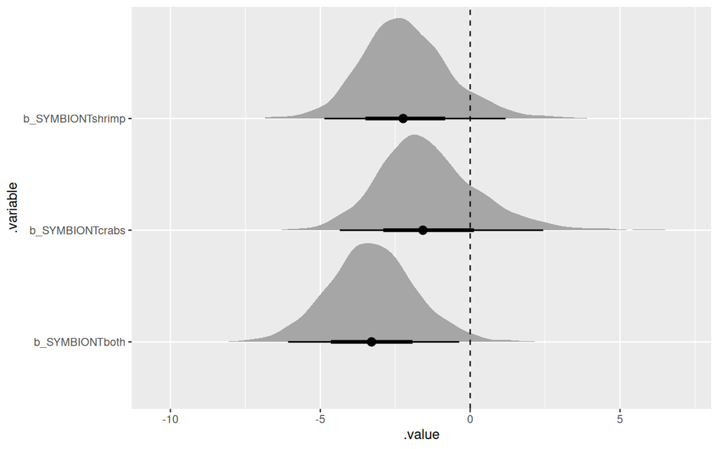

```r
mckeon_brm3 |>
    gather_draws(`^b_.*`, regex=TRUE) |>
    filter(.variable != 'b_Intercept') |>
    ggplot() +
    stat_halfeye(aes(x=.value,  y=.variable)) +
    geom_vline(xintercept = 0, linetype = 'dashed')
```

**density ridges (ggridges)**

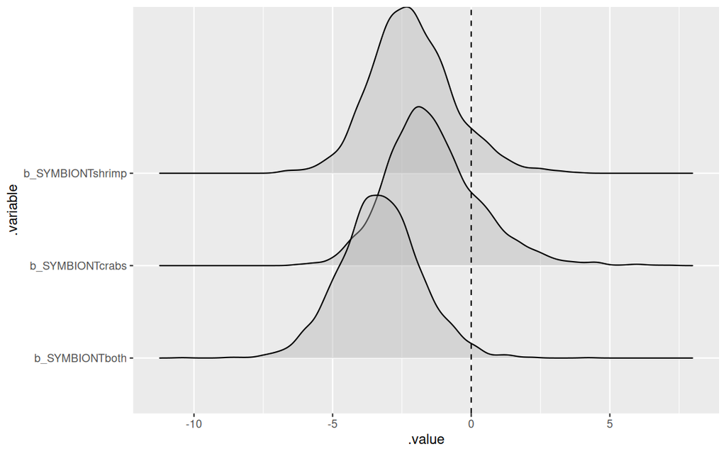

```r
mckeon_brm3 |>
    gather_draws(`^b_.*`, regex=TRUE) |>
    filter(.variable != 'b_Intercept') |>
    ggplot() +
    geom_density_ridges(aes(x=.value, y = .variable), alpha=0.4) +
    geom_vline(xintercept = 0, linetype = 'dashed')
```

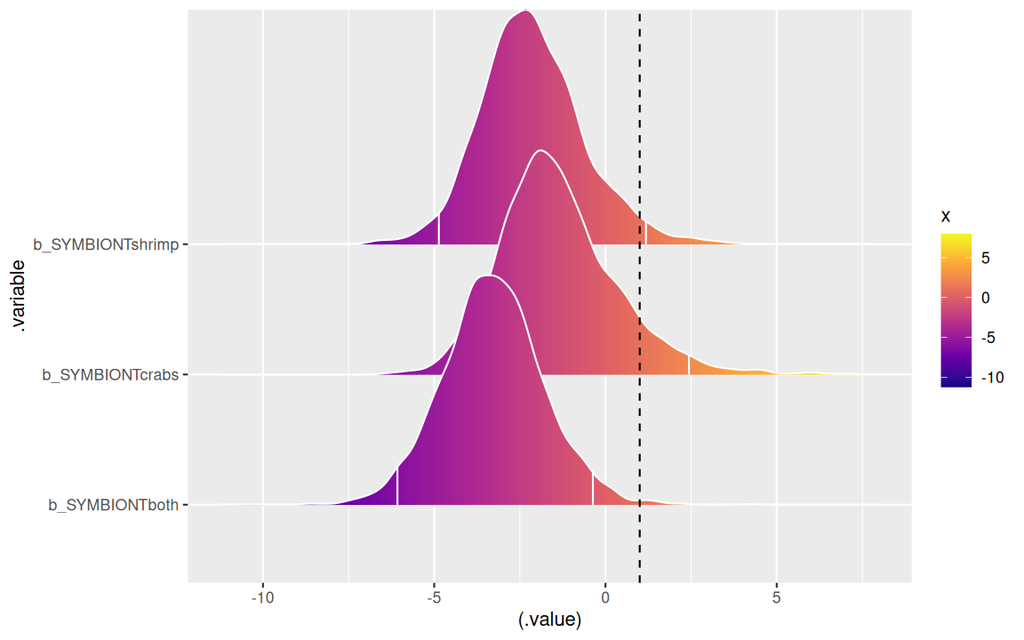

```r
##Or in colour
mckeon_brm3 |>
    gather_draws(`^b_.*`, regex=TRUE) |>
    filter(.variable != 'b_Intercept') |>
    ggplot() +
    geom_density_ridges_gradient(aes(x=(.value),
                                     y = .variable,
                                     fill = stat(x)),
                                 alpha=0.4, colour = 'white',
                                 quantile_lines = TRUE,
                                 quantiles = c(0.025, 0.975)) +
    geom_vline(xintercept = 1, linetype = 'dashed') +
    scale_x_continuous() +
    scale_fill_viridis_c(option = "C")
```

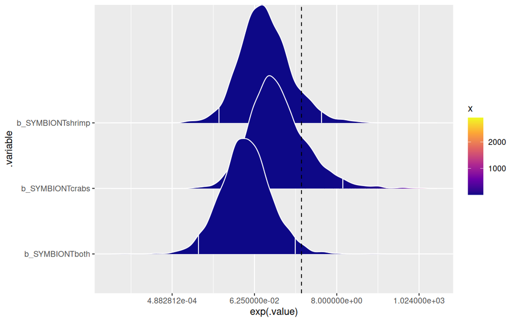

```r
## Fractional scale
mckeon_brm3 |>
    gather_draws(`^b_.*`, regex=TRUE) |>
    filter(.variable != 'b_Intercept') |>
    ggplot() +
    geom_density_ridges_gradient(aes(x=exp(.value),
                                     y = .variable,
                                     fill = stat(x)),
                                 alpha=0.4, colour = 'white',
                                 quantile_lines = TRUE,
                                 quantiles = c(0.025, 0.975)) +
    geom_vline(xintercept = 1, linetype = 'dashed') +
    scale_x_continuous(trans = scales::log2_trans()) +
    scale_fill_viridis_c(option = "C")
```

**tidy_draws**

```r
mckeon_brm3 |> tidy_draws()
```

```
# A tibble: 2,400 × 70
   .chain .iteration .draw b_Intercept b_SYMBIONTcrabs b_SYMBIONTshrimp
    <int>      <int> <int>       <dbl>           <dbl>            <dbl>
 1      1          1     1        2.12         -1.17             -1.39
 2      1          2     2        1.93         -0.519            -4.50
 3      1          3     3        2.25         -0.0653           -2.60
 4      1          4     4        2.00          1.70              2.44
 5      1          5     5        2.87         -1.60             -3.14
 6      1          6     6        2.22         -1.43             -2.86
 7      1          7     7        3.33          0.504            -1.70
 8      1          8     8        3.32         -1.53             -0.810
 9      1          9     9        3.76         -2.98             -4.02
10      1         10    10        3.49         -2.97             -2.14
# ℹ 2,390 more rows
# ℹ 64 more variables: b_SYMBIONTboth <dbl>, sd_BLOCK__Intercept <dbl>,
#   sd_BLOCK__SYMBIONTcrabs <dbl>, sd_BLOCK__SYMBIONTshrimp <dbl>,
#   sd_BLOCK__SYMBIONTboth <dbl>, cor_BLOCK__Intercept__SYMBIONTcrabs <dbl>,
#   cor_BLOCK__Intercept__SYMBIONTshrimp <dbl>,
#   cor_BLOCK__SYMBIONTcrabs__SYMBIONTshrimp <dbl>,
#   cor_BLOCK__Intercept__SYMBIONTboth <dbl>, …
```

**spread_draws**

```r
mckeon_brm3 |> spread_draws(`.*Intercept.*|b_SYMBIONT.*`,  regex=TRUE)
```

```
# A tibble: 2,400 × 23
   .chain .iteration .draw b_Intercept b_SYMBIONTcrabs b_SYMBIONTshrimp
    <int>      <int> <int>       <dbl>           <dbl>            <dbl>
 1      1          1     1        2.12         -1.17             -1.39
 2      1          2     2        1.93         -0.519            -4.50
 3      1          3     3        2.25         -0.0653           -2.60
 4      1          4     4        2.00          1.70              2.44
 5      1          5     5        2.87         -1.60             -3.14
 6      1          6     6        2.22         -1.43             -2.86
 7      1          7     7        3.33          0.504            -1.70
 8      1          8     8        3.32         -1.53             -0.810
 9      1          9     9        3.76         -2.98             -4.02
10      1         10    10        3.49         -2.97             -2.14
# ℹ 2,390 more rows
# ℹ 17 more variables: b_SYMBIONTboth <dbl>, sd_BLOCK__Intercept <dbl>,
#   cor_BLOCK__Intercept__SYMBIONTcrabs <dbl>,
#   cor_BLOCK__Intercept__SYMBIONTshrimp <dbl>,
#   cor_BLOCK__Intercept__SYMBIONTboth <dbl>, Intercept <dbl>,
#   `r_BLOCK[1,Intercept]` <dbl>, `r_BLOCK[2,Intercept]` <dbl>,
#   `r_BLOCK[3,Intercept]` <dbl>, `r_BLOCK[4,Intercept]` <dbl>, …
```

**posterior_samples**

```r
mckeon_brm3 |> posterior_samples() |> as_tibble()
```

```
# A tibble: 2,400 × 61
   b_Intercept b_SYMBIONTcrabs b_SYMBIONTshrimp b_SYMBIONTboth
         <dbl>           <dbl>            <dbl>          <dbl>
 1        2.12         -1.17             -1.39          -2.78
 2        1.93         -0.519            -4.50          -3.66
 3        2.25         -0.0653           -2.60          -3.38
 4        2.00          1.70              2.44          -4.52
 5        2.87         -1.60             -3.14          -0.647
 6        2.22         -1.43             -2.86          -2.94
 7        3.33          0.504            -1.70          -4.89
 8        3.32         -1.53             -0.810         -3.45
 9        3.76         -2.98             -4.02          -4.26
10        3.49         -2.97             -2.14          -4.12
# ℹ 2,390 more rows
# ℹ 57 more variables: sd_BLOCK__Intercept <dbl>,
#   sd_BLOCK__SYMBIONTcrabs <dbl>, sd_BLOCK__SYMBIONTshrimp <dbl>,
#   sd_BLOCK__SYMBIONTboth <dbl>, cor_BLOCK__Intercept__SYMBIONTcrabs <dbl>,
#   cor_BLOCK__Intercept__SYMBIONTshrimp <dbl>,
#   cor_BLOCK__SYMBIONTcrabs__SYMBIONTshrimp <dbl>,
#   cor_BLOCK__Intercept__SYMBIONTboth <dbl>, …
```

**\(R^2\)**

```r
mckeon_brm3 |>
    bayes_R2(re.form = NA, summary = FALSE) |>
    median_hdci()
```

```
          y        ymin      ymax .width .point .interval
1 0.1820312 0.002171857 0.3080653   0.95 median      hdci
```

```r
mckeon_brm3 |>
    bayes_R2(re.form = ~ (1 | BLOCK), summary = FALSE) |>
    median_hdci()
```

```
          y      ymin      ymax .width .point .interval
1 0.4687857 0.1217036 0.7405736   0.95 median      hdci
```

```r
## if we had random intercept/slope
mckeon_brm3 |>
    bayes_R2(re.form = ~ (SYMBIONT | BLOCK), summary = FALSE) |>
    median_hdci()
```

```
          y      ymin      ymax .width .point .interval
1 0.7073839 0.5620619 0.8216161   0.95 median      hdci
```

**Modelsummary**

```r
mckeon_brm3 |> modelsummary(
  statistic = c("conf.low", "conf.high"),
  shape = term ~ statistic,
  exponentiate = FALSE
)
```

|  | (1) Est. | (1) 2.5 % | (1) 97.5 % |
| --- | --- | --- | --- |
| b_Intercept | 2.863 | 1.069 | 5.294 |
| b_SYMBIONTcrabs | -1.577 | -4.349 | 2.437 |
| b_SYMBIONTshrimp | -2.236 | -4.865 | 1.182 |
| b_SYMBIONTboth | -3.291 | -6.074 | -0.367 |
| sd_BLOCK__Intercept | 1.954 | 0.194 | 4.730 |
| sd_BLOCK__SYMBIONTcrabs | 2.536 | 0.134 | 12.555 |
| sd_BLOCK__SYMBIONTshrimp | 1.861 | 0.078 | 8.162 |
| sd_BLOCK__SYMBIONTboth | 1.854 | 0.081 | 8.256 |
| cor_BLOCK__Intercept__SYMBIONTcrabs | 0.357 | -0.572 | 0.911 |
| cor_BLOCK__Intercept__SYMBIONTshrimp | 0.295 | -0.627 | 0.885 |
| cor_BLOCK__SYMBIONTcrabs__SYMBIONTshrimp | 0.471 | -0.579 | 0.926 |
| cor_BLOCK__Intercept__SYMBIONTboth | 0.218 | -0.654 | 0.871 |
| cor_BLOCK__SYMBIONTcrabs__SYMBIONTboth | 0.354 | -0.648 | 0.900 |
| cor_BLOCK__SYMBIONTshrimp__SYMBIONTboth | 0.425 | -0.629 | 0.921 |
| Num.Obs. | 80 |  |  |
| R2 | 0.707 |  |  |
| R2 Marg. | 0.182 |  |  |
| ICC | 0.9 |  |  |
| ELPD | -25.6 |  |  |
| ELPD s.e. | 6.0 |  |  |
| LOOIC | 51.3 |  |  |
| LOOIC s.e. | 12.0 |  |  |
| WAIC | 49.3 |  |  |
| RMSE | 0.21 |  |  |

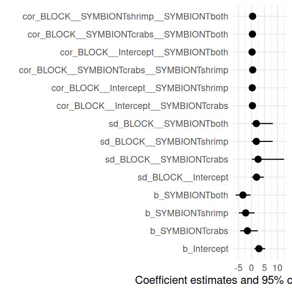

```r
mckeon_brm3 |> modelplot(exponentiate = FALSE)
```

# 10 Further analyses

In addition to comparing each of the symbiont types against the control group of no symbionts, it might be interesting to investigate whether there are any differences between the predation protection provided by crabs and shrimp, as well as whether having both crabs and shrimp symbionts is different to only a single symbiont type.

These contrasts can be explored via specific contrasts.

**Table** 1: Contrast coefficients

| SYMBIONT | Crab vs Shrimp | One vs Both | None vs Symbiont |
| --- | --- | --- | --- |
| none | 0 | 0 | 1 |
| crab | 1 | 1/2 | -1/3 |
| shrimp | -1 | 1/2 | -1/3 |
| both | 0 | -1 | -1/3 |

**brms**

**Pairwise comparisons**

```r
mckeon_brm3 |>
    emmeans(~SYMBIONT, type='response') |>
    pairs()
```

```
 contrast       odds.ratio lower.HPD upper.HPD
 none / crabs         4.84   0.00135      48.6
 none / shrimp        9.36   0.02041      78.6
 none / both         26.88   0.01456     284.2
 crabs / shrimp       1.92   0.00230      48.3
 crabs / both         5.82   0.00330     158.7
 shrimp / both        2.96   0.00193      41.7

Point estimate displayed: median
Results are back-transformed from the log odds ratio scale
HPD interval probability: 0.95
```

```r
# via tidy_draws
mckeon_em <-
    mckeon_brm3 |>
    emmeans(~SYMBIONT, type = "link") |>
    pairs() |>
    tidy_draws() |>
    mutate(across(starts_with("contrast"), exp)) |>
    summarise_draws(median,
                    HDInterval::hdi,
                    Pl = ~mean(.x < 1),
                    Pg = ~mean(.x > 1),
                    ROPE = ~ mean(.x < 1.1 & .x > 0.9)
                    )
mckeon_em
```

```
# A tibble: 6 × 7
  variable                median   lower upper     Pl    Pg   ROPE
  <chr>                    <dbl>   <dbl> <dbl>  <dbl> <dbl>  <dbl>
1 contrast none - crabs     4.84 0.00135  48.6 0.187  0.813 0.0246
2 contrast none - shrimp    9.36 0.0204   78.6 0.0833 0.917 0.0175
3 contrast none - both     26.9  0.0146  284.  0.0175 0.982 0.005
4 contrast crabs - shrimp   1.92 0.00230  48.3 0.327  0.673 0.0525
5 contrast crabs - both     5.82 0.00330 159.  0.125  0.875 0.0267
6 contrast shrimp - both    2.96 0.00193  41.7 0.217  0.783 0.0404
```

```r
# or via gather_emmeans_draws()
mckeon_em <-
    mckeon_brm3 |>
    emmeans(~SYMBIONT, type = "link") |>
    pairs() |>
    gather_emmeans_draws() |>
  mutate(.value = exp(.value)) |>
  summarise(median_hdci(.value),
    Pl = mean(.value < 1),
    Pg = mean(.value > 1)
    )
mckeon_em
```

```
# A tibble: 6 × 9
  contrast           y    ymin  ymax .width .point .interval     Pl    Pg
  <chr>          <dbl>   <dbl> <dbl>  <dbl> <chr>  <chr>      <dbl> <dbl>
1 crabs - both    5.82 0.00330 159.    0.95 median hdci      0.125  0.875
2 crabs - shrimp  1.92 0.00230  47.8   0.95 median hdci      0.327  0.673
3 none - both    26.9  0.0146  283.    0.95 median hdci      0.0175 0.982
4 none - crabs    4.84 0.00135  48.6   0.95 median hdci      0.187  0.813
5 none - shrimp   9.36 0.0204   78.5   0.95 median hdci      0.0833 0.917
6 shrimp - both   2.96 0.00193  41.4   0.95 median hdci      0.217  0.783
```

```r
## On a probability scale
mckeon_em <-
    mckeon_brm3 |>
    emmeans(~SYMBIONT, type = "link") |>
    regrid() |>
    pairs() |>
    tidy_draws() |>
    summarise_draws(median,
                    HDInterval::hdi,
                    Pl = ~mean(.x < 0),
                    Pg = ~mean(.x > 0)
                    )
mckeon_em
```

```
# A tibble: 6 × 6
  variable                median   lower upper     Pl    Pg
  <chr>                    <dbl>   <dbl> <dbl>  <dbl> <dbl>
1 contrast none - crabs   0.135  -0.164  0.602 0.187  0.813
2 contrast none - shrimp  0.257  -0.0821 0.718 0.0833 0.917
3 contrast none - both    0.512   0.0564 0.901 0.0175 0.982
4 contrast crabs - shrimp 0.0942 -0.431  0.615 0.327  0.673
5 contrast crabs - both   0.322  -0.169  0.852 0.125  0.875
6 contrast shrimp - both  0.214  -0.342  0.702 0.217  0.783
```

```r
# or via gather_emmeans_draws()
## mckeon_em <- mckeon_brm3 |>
##     emmeans(~SYMBIONT, type='link') |>
##     pairs() |>
##     gather_emmeans_draws() |>
##     mutate(Eff=exp(.value),
##            PEff=100*(Eff-1))#,
##              # Prob = plogis(.value))
## mckeon_em |> head()
## mckeon_em |>
##     group_by(contrast) |>
##     dplyr::select(contrast, Eff) |>
##     median_hdi()
## mckeon_em |>
##   group_by(contrast) |>
##   summarize(Prob=sum(Eff>1)/n())

## On a probability scale
mckeon_em <- mckeon_brm3 |>
    emmeans(~SYMBIONT, type='link') |>
    regrid() |>
    pairs() |>
    gather_emmeans_draws() |>
    mutate(Eff=.value)#,
mckeon_em |> head()
```

```
# A tibble: 6 × 6
# Groups:   contrast [1]
  contrast     .chain .iteration .draw   .value      Eff
  <chr>         <int>      <int> <int>    <dbl>    <dbl>
1 none - crabs     NA         NA     1  0.172    0.172
2 none - crabs     NA         NA     2  0.0692   0.0692
3 none - crabs     NA         NA     3  0.00581  0.00581
4 none - crabs     NA         NA     4 -0.0952  -0.0952
5 none - crabs     NA         NA     5  0.166    0.166
6 none - crabs     NA         NA     6  0.215    0.215
```

```r
mckeon_em |>
    group_by(contrast) |>
    dplyr::select(contrast, Eff) |>
    median_hdi()
```

```
# A tibble: 6 × 7
  contrast          Eff  .lower .upper .width .point .interval
  <chr>           <dbl>   <dbl>  <dbl>  <dbl> <chr>  <chr>
1 crabs - both   0.322  -0.169   0.852   0.95 median hdi
2 crabs - shrimp 0.0942 -0.431   0.615   0.95 median hdi
3 none - both    0.512   0.0430  0.891   0.95 median hdi
4 none - crabs   0.135  -0.164   0.602   0.95 median hdi
5 none - shrimp  0.257  -0.0821  0.718   0.95 median hdi
6 shrimp - both  0.214  -0.321   0.724   0.95 median hdi
```

```r
## Cell means
mckeon_em = emmeans(mckeon_brm3, ~SYMBIONT, type='link') |>
      gather_emmeans_draws()
mckeon_em |> mutate(P=plogis(.value)) |> median_hdci(P)
```

```
# A tibble: 4 × 7
  SYMBIONT     P .lower .upper .width .point .interval
  <fct>    <dbl>  <dbl>  <dbl>  <dbl> <chr>  <chr>
1 none     0.946 0.786   0.999   0.95 median hdci
2 crabs    0.801 0.318   1.000   0.95 median hdci
3 shrimp   0.676 0.221   0.994   0.95 median hdci
4 both     0.410 0.0362  0.899   0.95 median hdci
```

**Specific contrasts**

```r
cmat <- cbind(
    "Crab vs shrimp" =c(0,1,-1,0),
    "Both vs One"=c(0,-1/2,-1/2,1),
    "Any vs None"=c(-1, 1/3, 1/3, 1/3)
)

mckeon_em <- mckeon_brm3 |>
    emmeans(~SYMBIONT, type = 'response') |>
    contrast(method = list(cmat))
mckeon_em <-
    mckeon_brm3 |>
    emmeans(~SYMBIONT, type = "link") |>
    contrast(method = list(cmat)) |>
    tidy_draws() |>
    mutate(across(starts_with("contrast"), exp)) |>
    summarise_draws(median,
                    HDInterval::hdi,
                    Pl = ~mean(.x < 1),
                    Pg = ~mean(.x > 1)
                    )
mckeon_em
```

```
# A tibble: 3 × 6
  variable                median     lower  upper    Pl     Pg
  <chr>                    <dbl>     <dbl>  <dbl> <dbl>  <dbl>
1 contrast Crab vs shrimp 1.92   0.00230   48.3   0.327 0.673
2 contrast Both vs One    0.232  0.0000421  2.05  0.872 0.128
3 contrast Any vs None    0.0995 0.00252    0.794 0.962 0.0379
```

```r
## or via gather_emmeans_draws
mckeon_em <-
  mckeon_brm3 |>
    emmeans(~SYMBIONT, type='link') |>
    contrast(method=list(cmat)) |>
    gather_emmeans_draws() |>
  mutate(Fit=exp(.value)) |>
  summarise(median_hdci(Fit),
    Pl =  mean(Fit < 0),
    Pg =  mean(Fit > 0)
    )
mckeon_em
```

```
# A tibble: 3 × 9
  contrast            y      ymin   ymax .width .point .interval    Pl    Pg
  <chr>           <dbl>     <dbl>  <dbl>  <dbl> <chr>  <chr>     <dbl> <dbl>
1 Any vs None    0.0995 0.00252    0.794   0.95 median hdci          0     1
2 Both vs One    0.232  0.0000421  2.05    0.95 median hdci          0     1
3 Crab vs shrimp 1.92   0.00230   47.8     0.95 median hdci          0     1
```

```r
newdata <- emmeans(mckeon_brm3, ~SYMBIONT, type = "response") |> as.data.frame()
head(newdata)
```

```
 SYMBIONT  response lower.HPD upper.HPD
 none     0.9459864 0.7861349 0.9994666
 crabs    0.8006708 0.3179100 0.9999727
 shrimp   0.6759535 0.2277978 0.9992090
 both     0.4095677 0.0228237 0.8856309

Point estimate displayed: median
Results are back-transformed from the logit scale
HPD interval probability: 0.95
```

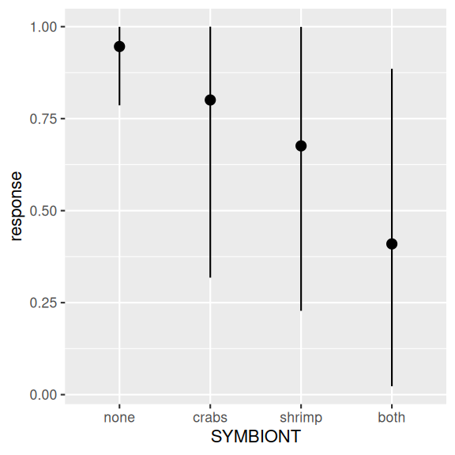

```r
ggplot(newdata, aes(y=response, x=SYMBIONT)) +
    geom_pointrange(aes(ymin=lower.HPD, ymax=upper.HPD))
```

**R^2**

```r
mckeon_brm3 |> bayes_R2(re.form=NA)
```

```
    Estimate Est.Error       Q2.5   Q97.5
R2 0.1739922 0.0875243 0.01229385 0.32176
```

```r
mckeon_brm3 |> bayes_R2(re.form=NA, summary=FALSE) |> median_hdci()
```

```
          y        ymin      ymax .width .point .interval
1 0.1820312 0.002171857 0.3080653   0.95 median      hdci
```

```r
mckeon_brm3 |> bayes_R2(re.form=~(1|BLOCK), summary=FALSE) |> median_hdci()
```

```
          y      ymin      ymax .width .point .interval
1 0.4687857 0.1217036 0.7405736   0.95 median      hdci
```

```r
## for random intercept/slope model
mckeon_brm3 |> bayes_R2(re.form=~(SYMBIONT|BLOCK), summary=FALSE) |> median_hdci()
```

```
          y      ymin      ymax .width .point .interval
1 0.7073839 0.5620619 0.8216161   0.95 median      hdci
```

## 11 References

Mckeon, Seabird, Adrian Stier, Shelby Mcilroy, and Benjamin Bolker. 2012. “Multiple Defender Effects: Synergistic Coral Defense by Mutualist Crustaceans.” *Oecologia* 169 (February): 1095–1103. https://doi.org/10.1007/s00442-012-2275-2.